# ECG Signal Preprocessing

Jenna Lu

2026-07-27

# Overview

Physiological signals often contain measurement noise, baseline drift, and artifacts that must be addressed before statistical analysis.

This notebook preprocesses ECG recordings from the WESAD dataset by applying signal filtering techniques and preparing the data for downstream heart rate and heart rate variability analysis.

The goals are:

1. Load raw ECG recordings
2. Apply a bandpass filter to reduce noise
3. Compare raw and filtered signals
4. Prepare ECG signals for cardiac feature extraction

# Libraries

```r
library(tidyverse)
library(here)
library(signal)
```

# Load ECG Data

We begin with participant S2 from the WESAD dataset.

```r
ecg_data <- read_csv(
  here("data", "processed", "S2_ecg.csv")
)
glimpse(ecg_data)
```

```
## Rows: 4,255,300
## Columns: 3
## $ time  <dbl> 0.000000000, 0.001428571, 0.002857143, 0.004285714, 0.005714286,…
## $ ecg   <dbl> 0.0214233398, 0.0203247070, 0.0165252686, 0.0167083740, 0.011672…
## $ label <dbl> 0, 0, 0, 0, 0, 0, 0, 0, 0, 0, 0, 0, 0, 0, 0, 0, 0, 0, 0, 0, 0, 0…
```

# Sampling Frequency

The WESAD chest ECG signal is sampled at approximately 700 Hz.

```r
fs <- 700

fs
```

```
## [1] 700
```

# Visualize Raw ECG

The raw ECG signal contains both physiological information and potential noise.

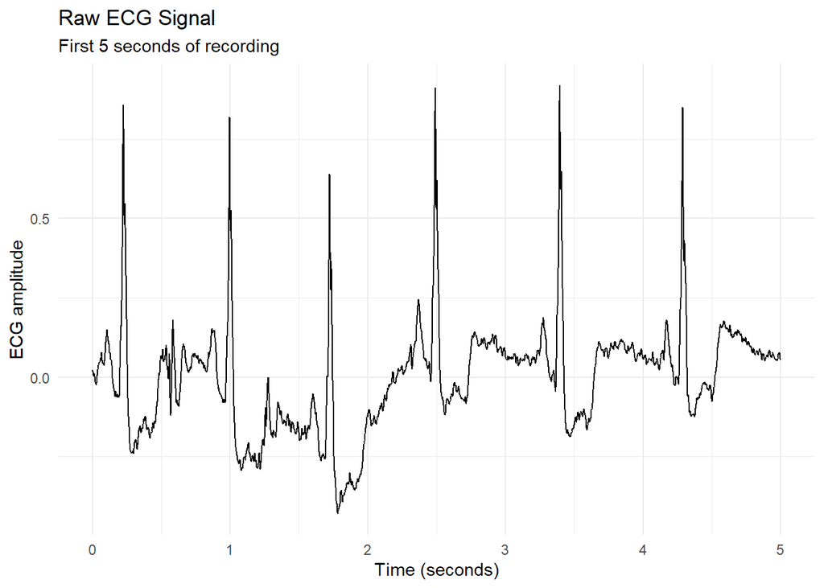

```r
ecg_data %>%
  slice(1:3500) %>%
  ggplot(
    aes(
      x = time,
      y = ecg
    )
  ) +
  geom_line() +
  labs(
    title = "Raw ECG Signal",
    subtitle = "First 5 seconds of recording",
    x = "Time (seconds)",
    y = "ECG amplitude"
  ) +
  theme_minimal()
```

# ECG Filtering

## Motivation

ECG preprocessing commonly uses bandpass filtering to preserve cardiac frequency components while reducing baseline drift and high-frequency noise.

A Butterworth filter is applied using:

- Low cutoff: 0.5 Hz
- High cutoff: 40 Hz

This range preserves the primary ECG morphology needed for heartbeat detection.

```r
# Define Butterworth bandpass filter

ecg_filter <- butter(
  n = 4,
  W = c(0.5, 40) / (fs / 2),
  type = "pass"
)


# Apply zero-phase filtering

filtered_ecg <- filtfilt(
  ecg_filter,
  ecg_data$ecg
)


# Add filtered signal

ecg_data <- ecg_data %>%
  mutate(
    filtered_ecg = filtered_ecg
  )
```

# Compare Raw and Filtered ECG

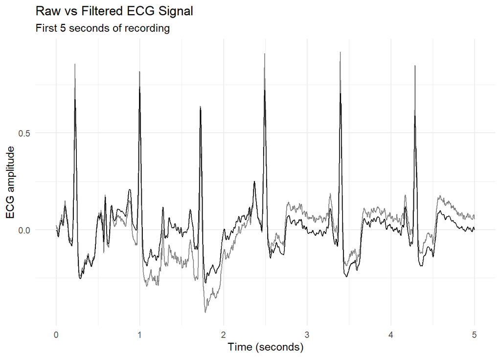

```r
ecg_data %>%
  slice(1:3500) %>%
  ggplot(
    aes(x=time)
  ) +
  geom_line(
    aes(y=ecg),
    alpha=0.5
  ) +
  geom_line(
    aes(y=filtered_ecg)
  ) +
  labs(
    title="Raw vs Filtered ECG Signal",
    subtitle="First 5 seconds of recording",
    x="Time (seconds)",
    y="ECG amplitude"
  ) +
  theme_minimal()
```

# Inspect Filtered Signal

The filtered signal will be used for detecting cardiac peaks and estimating beat-to-beat intervals.

```r
ecg_data %>%
  select(
    time,
    filtered_ecg,
    label
  ) %>%
  head()
```

```
## # A tibble: 6 × 3
##      time filtered_ecg label
##     <dbl>        <dbl> <dbl>
## 1 0           -0.00751     0
## 2 0.00143     -0.00595     0
## 3 0.00286     -0.00472     0
## 4 0.00429     -0.00392     0
## 5 0.00571     -0.00366     0
## 6 0.00714     -0.00400     0
```

# Save Preprocessed Data

The filtered ECG signal is saved for downstream heart rate and HRV analysis.

```r
write_csv(
  ecg_data,
  here(
    "data",
    "processed",
    "S2_ecg_filtered.csv"
  )
)
```

# Summary

This preprocessing pipeline removes high-frequency noise and baseline variation from raw ECG recordings while preserving cardiac waveform characteristics.

The resulting filtered ECG signal will be used for cardiac feature extraction, including R-peak detection, heart rate estimation, and heart rate variability analysis.